# Perceived Barriers to Healthcare Access Among Women in Tanzania: Evidence from the 2015–16 Tanzania DHS

Allan Yienya | Data Source: Tanzania Demographic and Health Survey (Individual Recode file, TZIR7BFL)

## Introduction

Access to healthcare is shaped not only by the availability of services but by the practical and social obstacles women face in reaching them. Even where facilities exist, barriers such as the cost of treatment, distance, and the need for permission or company can delay or prevent care-seeking altogether — with consequences for maternal health, chronic disease management, and overall wellbeing.

This report uses the Tanzania Demographic and Health Survey (TDHS) individual recode file to examine four self-reported barriers to accessing healthcare among women of reproductive age: needing permission to seek treatment, lacking money for treatment, distance to a health facility, and not wanting to go alone. Each barrier is examined overall and across two socio-demographic factors — educational attainment and age — to identify which groups face the greatest obstacles and where interventions might be best targeted.

## Findings

### Cost is the most widely reported barrier, followed by distance

Among the four barriers examined, **lack of money for treatment** is the most commonly cited obstacle, with **48.9%** of women describing it as a big problem — effectively coin-flip odds that cost alone stands between a woman and care. **Distance to a health facility** follows, cited as a big problem by **39.9%** of respondents. **Not wanting to go alone** is reported by **28.3%**, while needing **permission to seek treatment** is the least widely reported barrier, at **12.2%**. This ordering suggests that structural and economic barriers (cost, distance) affect far more women than social or autonomy-related barriers (permission, companionship) in this setting.

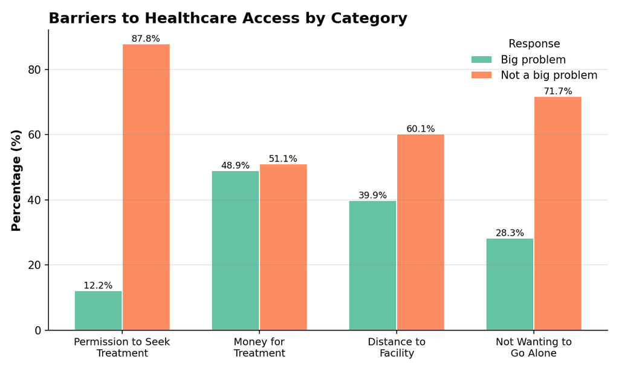

Figure 1. Percentage of women reporting each barrier as a "big problem" vs. "not a big problem."

### Barriers decline sharply with education, especially for cost

Every barrier examined is less commonly reported as education rises, and the gradient is steepest for financial barriers. Among women with **no education**, **62.5%** report money for treatment as a big problem, compared with just **14.9%** of women with **higher education** — a more than four-fold difference. A similar, though less pronounced, pattern holds for distance to a facility (**51.3%** among women with no education vs. **23.4%** among those with higher education) and for not wanting to go alone (**34.4%** vs. **15.6%**). Needing permission shows the smallest gap by education (**13.6%** vs. **9.2%**), reinforcing that education is most strongly tied to the barriers rooted in economic resources and facility access, rather than social autonomy.

### Age shows a modest, and sometimes counter-intuitive, relationship with barriers

Unlike education, age shows weaker and less consistent patterns. The share reporting money for treatment as a big problem *rises* with age — from **43.9%** among 15–19-year-olds to **56.9%** among 45–49-year-olds — possibly reflecting that older women are more often the ones directly responsible for finding treatment funds, while younger women may still rely on parents or a partner. Distance to a facility follows a similarly gentle upward trend (**37.1%** to **43.1%**). By contrast, needing permission to seek treatment is highest among the youngest women (**15.3%** at ages 15–19) and declines with age, consistent with younger women having less autonomy over their own healthcare decisions.

### Younger and less-educated women are broadly overrepresented in the sample

The sample skews young, with a median age of **27** and an interquartile range of **20–36** years (Figure 2). Educational attainment is concentrated at the primary level: **57.6%** of women have primary education, **26.3%** secondary, **15.1%** no formal education, and only **1.1%** higher education (Figure 3). Because so few women have higher education, estimates for that group should be interpreted with some caution given the smaller sample size.

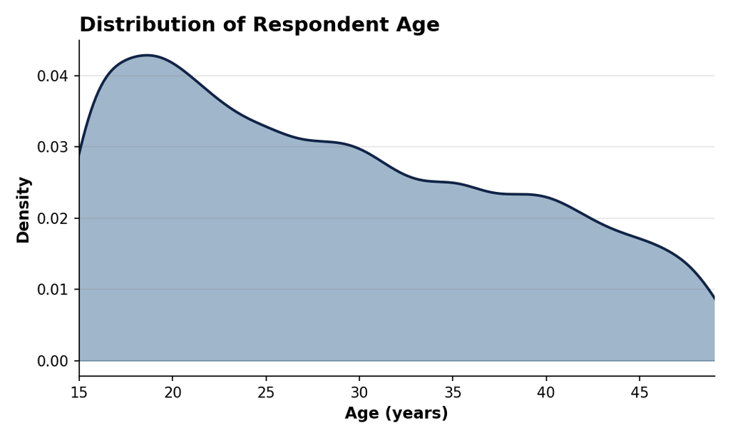

Figure 2. Distribution of respondent age.

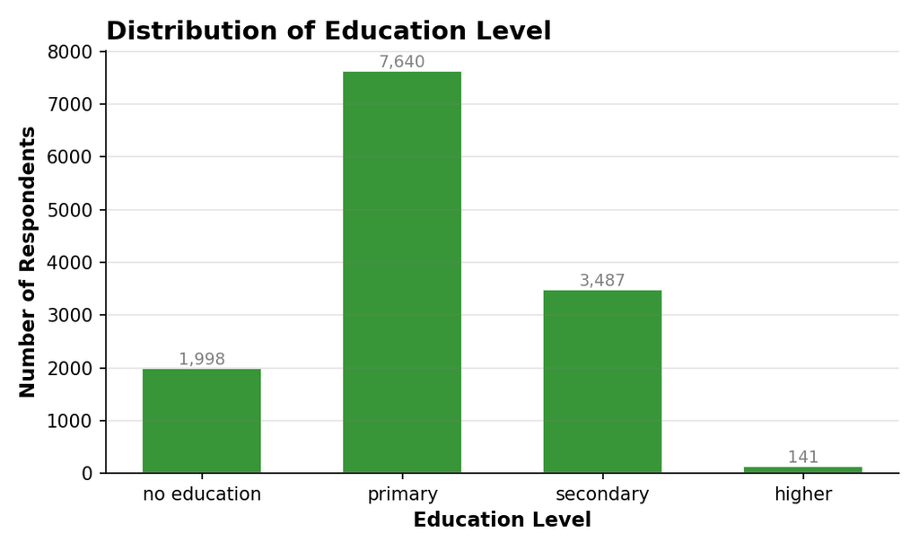

Figure 3. Distribution of education level.

## Data Presentation

The relationship between age and education is itself worth noting: the boxplot below shows that women with no education and primary education tend to be somewhat older on average than those with secondary or higher education, consistent with younger cohorts in Tanzania having greater access to schooling than earlier generations.

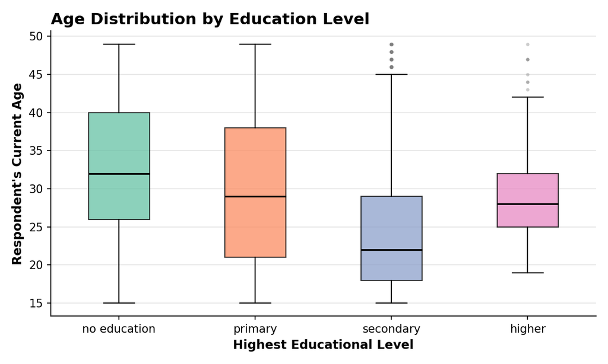

Figure 4. Age distribution by highest education level attained.

Table 1. Summary of Perceived Barriers to Healthcare Access

| Barrier | Big Problem (%) | Not a Big Problem (%) |
| --- | --- | --- |
| Money for treatment | 48.9 | 51.1 |
| Distance to facility | 39.9 | 60.1 |
| Not wanting to go alone | 28.3 | 71.7 |
| Permission to seek treatment | 12.2 | 87.8 |

Source: Tanzania DHS, Individual Recode file (TZIR7BFL), N = 13,266 women aged 15–49.

## Conclusion

These findings point to **cost and distance**, not social or permission-related constraints, as the dominant barriers to healthcare access among Tanzanian women. Both barriers are strongly patterned by education: women with no formal education are consistently the most disadvantaged group across every barrier measured, and the gap is most dramatic for financial access. Age plays a secondary role, with older women somewhat more likely to cite cost and distance as problems, while younger women more often report needing permission — a marker of limited healthcare autonomy at younger ages.

**Recommendations:**

- Prioritize **financial protection mechanisms** (e.g., subsidized care, health insurance enrollment drives) targeted at women with no or only primary education, who report the highest rates of cost-related barriers.
- Expand **facility outreach and mobile/community health services** in areas where distance remains a major obstacle, particularly for older and less-educated women.
- Pair financial and infrastructural interventions with **girls' education initiatives**, since education is associated with lower reported barriers across nearly every dimension measured.
- Address the **permission and autonomy barrier** among adolescents and young women specifically, through interventions that engage families and partners in supporting young women's independent healthcare decisions.